# Predicting Used Car Prices

Charles Lu

### Introduction

To many Americans, car ownership is a symbol of both independence and freedom, but many don't know where to start when it comes to buying their first car. Common wisdom recommends traversing the used car market, but navigating it is confusing and dangerous. There are a number of factors to consider in evaluating the value of a car, including the make, year, condition, and mileage, among others. As a beginner with minimal car experience, it is easy to accidentally overpay for a vehicle. The goal of this tutorial is to help users navigate the 195.84 billion dollar industry by helping users value different used cars, while also learning about the data science pipeline.

### Data Collection

The first step in the data science pipeline is data collection. This includes both finding data as well as parsing it to prepare it for the rest of the steps in the data science process. For this project, we will use a dataset that is scraped from craigslist, which you can download with a Kaggle account from [here](https://www.kaggle.com/datasets/austinreese/craigslist-carstrucks-data). Move the csv file into the same folder as this notebook, and you should be set. Before we get started, we need to import python libraries that we will use. The different libraries that we will use are

1. [Matplotlib](https://matplotlib.org/stable/index.html)
2. [Numpy](https://numpy.org/doc/1.24/)
3. [Pandas](https://pandas.pydata.org/docs/)
4. [Seaborn](https://seaborn.pydata.org/tutorial.html)

```python
import matplotlib
import matplotlib.pyplot as plt
from matplotlib.pyplot import figure
import numpy as np
import pandas as pd
import seaborn as sns
```

After importing the appropriate libraries, we will read the data into a pandas dataframe object. We will call this dataframe df.

```python
# read in the data
df = pd.read_csv('vehicles.csv')
```

```python
df.head(10)
```

|  | id | url | region | region_url | price | year | manufacturer | model | condition | cylinders | ... | size | type | paint_color | image_url | description | county | state | lat | long | posting_date |
| --- | --- | --- | --- | --- | --- | --- | --- | --- | --- | --- | --- | --- | --- | --- | --- | --- | --- | --- | --- | --- | --- |
| 0 | 7222695916 | https://prescott.craigslist.org/cto/d/prescott... | prescott | https://prescott.craigslist.org | 6000 | NaN | NaN | NaN | NaN | NaN | ... | NaN | NaN | NaN | NaN | NaN | NaN | az | NaN | NaN | NaN |
| 1 | 7218891961 | https://fayar.craigslist.org/ctd/d/bentonville... | fayetteville | https://fayar.craigslist.org | 11900 | NaN | NaN | NaN | NaN | NaN | ... | NaN | NaN | NaN | NaN | NaN | NaN | ar | NaN | NaN | NaN |
| 2 | 7221797935 | https://keys.craigslist.org/cto/d/summerland-k... | florida keys | https://keys.craigslist.org | 21000 | NaN | NaN | NaN | NaN | NaN | ... | NaN | NaN | NaN | NaN | NaN | NaN | fl | NaN | NaN | NaN |
| 3 | 7222270760 | https://worcester.craigslist.org/cto/d/west-br... | worcester / central MA | https://worcester.craigslist.org | 1500 | NaN | NaN | NaN | NaN | NaN | ... | NaN | NaN | NaN | NaN | NaN | NaN | ma | NaN | NaN | NaN |
| 4 | 7210384030 | https://greensboro.craigslist.org/cto/d/trinit... | greensboro | https://greensboro.craigslist.org | 4900 | NaN | NaN | NaN | NaN | NaN | ... | NaN | NaN | NaN | NaN | NaN | NaN | nc | NaN | NaN | NaN |
| 5 | 7222379453 | https://hudsonvalley.craigslist.org/cto/d/west... | hudson valley | https://hudsonvalley.craigslist.org | 1600 | NaN | NaN | NaN | NaN | NaN | ... | NaN | NaN | NaN | NaN | NaN | NaN | ny | NaN | NaN | NaN |
| 6 | 7221952215 | https://hudsonvalley.craigslist.org/cto/d/west... | hudson valley | https://hudsonvalley.craigslist.org | 1000 | NaN | NaN | NaN | NaN | NaN | ... | NaN | NaN | NaN | NaN | NaN | NaN | ny | NaN | NaN | NaN |
| 7 | 7220195662 | https://hudsonvalley.craigslist.org/cto/d/poug... | hudson valley | https://hudsonvalley.craigslist.org | 15995 | NaN | NaN | NaN | NaN | NaN | ... | NaN | NaN | NaN | NaN | NaN | NaN | ny | NaN | NaN | NaN |
| 8 | 7209064557 | https://medford.craigslist.org/cto/d/grants-pa... | medford-ashland | https://medford.craigslist.org | 5000 | NaN | NaN | NaN | NaN | NaN | ... | NaN | NaN | NaN | NaN | NaN | NaN | or | NaN | NaN | NaN |
| 9 | 7219485069 | https://erie.craigslist.org/cto/d/erie-2012-su... | erie | https://erie.craigslist.org | 3000 | NaN | NaN | NaN | NaN | NaN | ... | NaN | NaN | NaN | NaN | NaN | NaN | pa | NaN | NaN | NaN |

10 rows × 26 columns

As we can see above, the data comes with a lot of information that won't be relevant for our purposes, so we will use the [drop](https://pandas.pydata.org/docs/reference/api/pandas.DataFrame.drop.html) function to drop irrelevant information such as the description, id, url of images, etc. There are also entries that are incomplete, without information for important features such as price, year, and mileage (odometer). We will use the [dropna](https://pandas.pydata.org/docs/reference/api/pandas.DataFrame.dropna.html) function from pandas to drop any entries in our dataframe that don't contain information on these important features. It is important to note that this could [introduce bias](https://www-users.york.ac.uk/~mb55/intro/typemiss4.htm) into our dataset, but we will operate under the assumption that the data is missing completely at random for simplicity purposes.

```python
# remove useless columns
df.drop(columns=['id', 'url', 'region_url' , 'VIN', 'image_url', 'description', 'lat', 'long', 'posting_date', 'county', 'size', 'type', 'drive', 'title_status', 'cylinders', 'region'], inplace=True)

# remove cars without data on price, year, manufacturer, model, condition, odometer (mileage)
df.dropna(subset=['price', 'year', 'manufacturer', 'model', 'condition', 'odometer'], inplace=True)
df.head(10)
```

|  | price | year | manufacturer | model | condition | fuel | odometer | transmission | paint_color | state |
| --- | --- | --- | --- | --- | --- | --- | --- | --- | --- | --- |
| 27 | 33590 | 2014.0 | gmc | sierra 1500 crew cab slt | good | gas | 57923.0 | other | white | al |
| 28 | 22590 | 2010.0 | chevrolet | silverado 1500 | good | gas | 71229.0 | other | blue | al |
| 29 | 39590 | 2020.0 | chevrolet | silverado 1500 crew | good | gas | 19160.0 | other | red | al |
| 30 | 30990 | 2017.0 | toyota | tundra double cab sr | good | gas | 41124.0 | other | red | al |
| 31 | 15000 | 2013.0 | ford | f-150 xlt | excellent | gas | 128000.0 | automatic | black | al |
| 32 | 27990 | 2012.0 | gmc | sierra 2500 hd extended cab | good | gas | 68696.0 | other | black | al |
| 33 | 34590 | 2016.0 | chevrolet | silverado 1500 double | good | gas | 29499.0 | other | silver | al |
| 34 | 35000 | 2019.0 | toyota | tacoma | excellent | gas | 43000.0 | automatic | grey | al |
| 35 | 29990 | 2016.0 | chevrolet | colorado extended cab | good | gas | 17302.0 | other | red | al |
| 36 | 38590 | 2011.0 | chevrolet | corvette grand sport | good | gas | 30237.0 | other | red | al |

Much better. Our data is almost ready. There is still one problem, though. The model column of our dataframe is labeled consistently. As we can see above, some models of car are very similar, but have different names. For example, our dataframe considers a silverado 1500 to be different from a silverado 1500 crew. For the purposes of our model, we will group these together to be the same car. We will do so by making a new column in our dataframe that takes the first word in the manufacturer column and combines it with the first word of the model. A manufacturer gmc model sierra 1500 crew cab slt would simply be a gmc sierra. Lets call this column "car." Also, we have many different car manufacturers in our dataset. Out of tens of thousands of datapoints, there are only 19 Ferraris. Lets focus on the 12 most common manufacturers for simplicity. We also filtered out used cars selling for over $100k USD, since those are extreme outliers. We are now ready for the next step in the data science pipeline.

```python
# make a new column for the car
df['car'] = df['manufacturer'].str.split(" ").str[0] + " " + df['model'].str.split(" ").str[0]

# we are only interested with used cars under 100k
df = df[df['price'] < 100000]

# lets just use the 12 most common used vehicle manufacturers
print(df['manufacturer'].value_counts())
df = df[(df['manufacturer'] == 'ford') | (df['manufacturer'] == 'chevrolet') | (df['manufacturer'] == 'toyota') | (df['manufacturer'] == 'honda') | (df['manufacturer'] == 'nissan') | (df['manufacturer'] == 'jeep') | (df['manufacturer'] == 'bmw') | (df['manufacturer'] == 'gmc') | (df['manufacturer'] == 'ram') | (df['manufacturer'] == 'dodge') | (df['manufacturer'] == 'mercedes-benz') | (df['manufacturer'] == 'volkswagen')]
```

```
ford               37190
chevrolet          31740
toyota             20340
honda              12784
nissan             10949
jeep               10335
gmc                 9257
bmw                 9099
ram                 7918
dodge               7503
mercedes-benz       6476
volkswagen          6188
hyundai             5974
subaru              5514
lexus               5250
audi                5199
kia                 4890
acura               4459
cadillac            4437
chrysler            3619
buick               3605
mazda               3575
infiniti            3533
lincoln             3024
volvo               2443
mitsubishi          2318
mini                1593
jaguar              1546
pontiac             1463
rover               1035
mercury              824
alfa-romeo           747
porsche              711
saturn               685
tesla                667
fiat                 564
harley-davidson       74
datsun                40
ferrari               19
aston-martin          11
land rover            10
Name: manufacturer, dtype: int64
```

### Data Exploration

Now that we have finished collecting our data, we are ready for the next step, which is data exploration. Lets create some graphs to visualize our daata and get a better feel for what we are working with. The first graph we will create is a simple graph showing the prices of the cars we are working with.

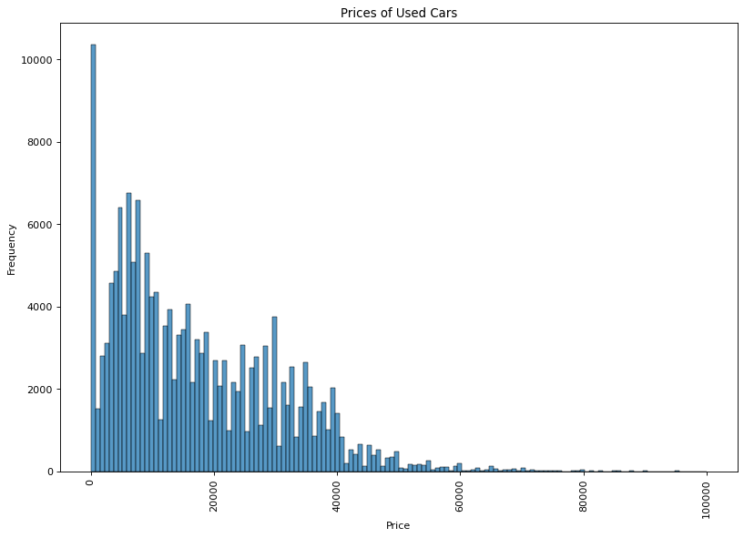

```python
figure(figsize=(12, 8), dpi=80)
sns.histplot(df['price'])
plt.xlabel('Price')
plt.ylabel('Frequency')
plt.title('Prices of Used Cars')
plt.xticks(rotation=90);
```

As we can see, most used cars cost around $0 - $20,000, but there are still a significant amount of cars in the $20,000 - $40,000 price range. For our next plot, we will create a [violin plot](https://chartio.com/learn/charts/violin-plot-complete-guide/#:~:text=What%20is%20a%20violin%20plot,data%20points%20in%20each%20region.). Violin plots are great for depicting distributions between multiple groups, since the width of each "violin" is its frequency. Below is a violin plot showing the price of cars based on manufacturer. The gray bar in the middle shows the cost of an average car for each manufacturer. As expected, hondas are the cheapest, but interestingly brands such as GMC and Ram are most expensive.

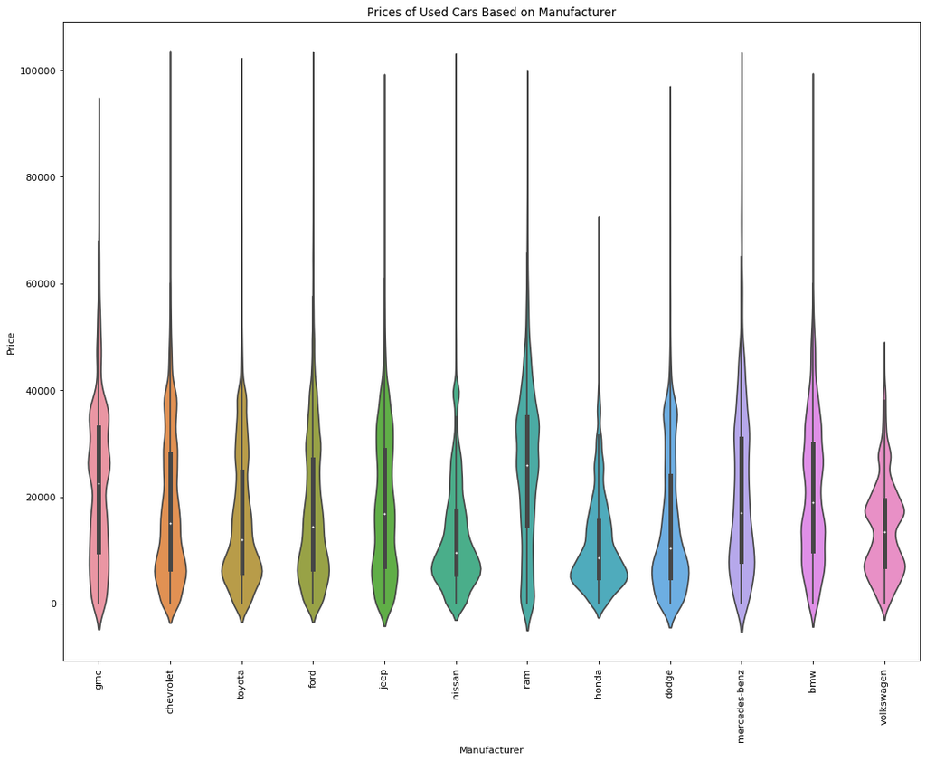

```python
# lets look at the price based on manufacturer

figure(figsize=(16, 12), dpi=80)
sns.violinplot(data=df, x="manufacturer", y="price", )
plt.xlabel('Manufacturer')
plt.ylabel('Price')
plt.title('Prices of Used Cars Based on Manufacturer')
plt.xticks(rotation=90);
```

Now lets make a scatterplot showing the price of cars based on mileage. The graph is cluttered, but we can see a general correlation between mileage and price. As expected, more miles = lower value.

```
(0.0, 1000000.0)
```

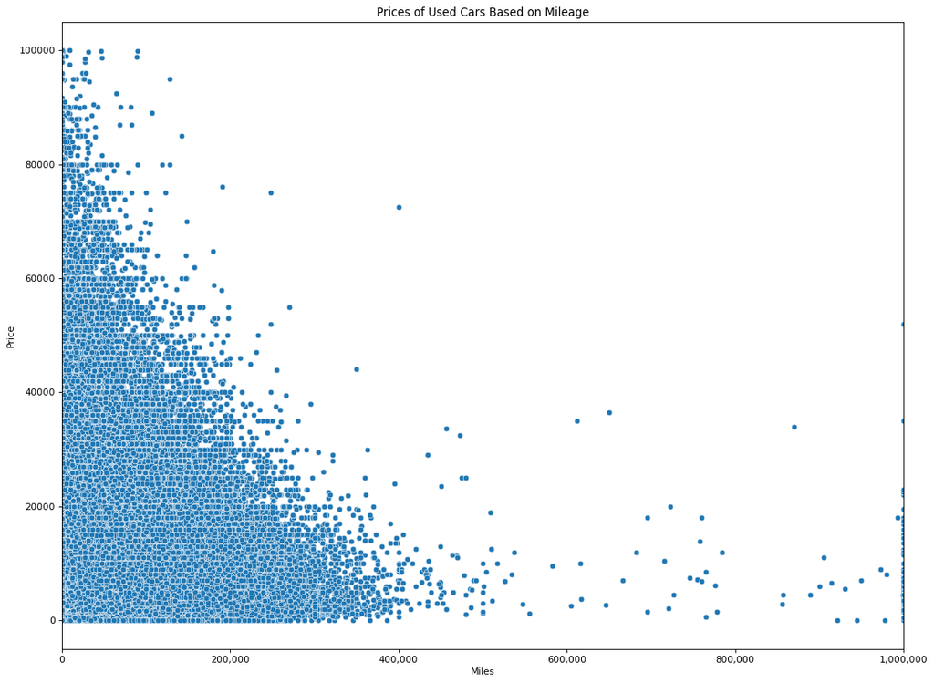

```python
# plot price based on mileage

figure(figsize=(16, 12), dpi=80)
sns.scatterplot(data=df, x="odometer", y="price")
plt.xlabel('Miles')
plt.ylabel('Price')
plt.title('Prices of Used Cars Based on Mileage')
plt.xticks([0, 200000, 400000, 600000, 800000, 1000000], ['0', '200,000', '400,000', '600,000', '800,000', '1,000,000'])
plt.xlim(0, 1000000)
```

We can also see the price based on the different types of fuel it uses. Below is a box plot showing just that. The black lines in the box show the median price, and interestingly electric cars are similarly priced to gas cars, while hybrid cars are actually cheaper. This may be because these cars age worse, since battery replacements will be required soon and are expensive.

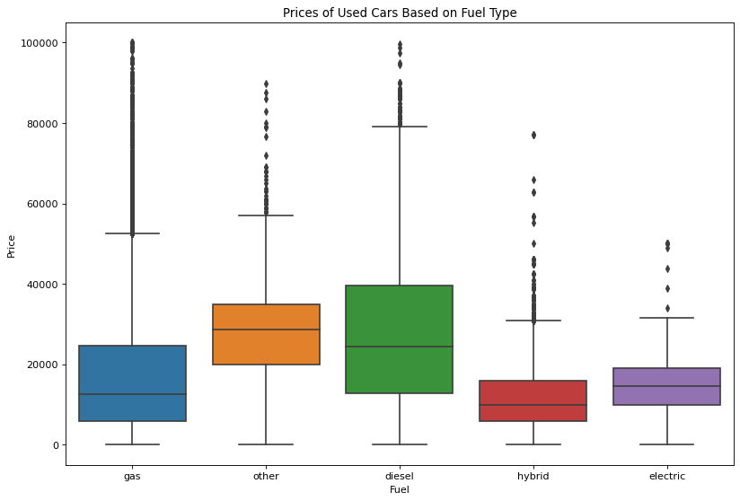

```python
# price based on fuel

figure(figsize=(12, 8), dpi=80)
sns.boxplot(data = df, x = 'fuel', y ='price')
plt.xlabel('Fuel')
plt.ylabel('Price')
plt.title('Prices of Used Cars Based on Fuel Type')
```

For this next plot, we will look at how price changes based on the year the car was made in. Our original data represented year using floats, but lets change that to integers, since the year will never be a non whole number. The graph shows what we expected; newer cars are more valuable, but very very old cars become valuable again because of their rarity.

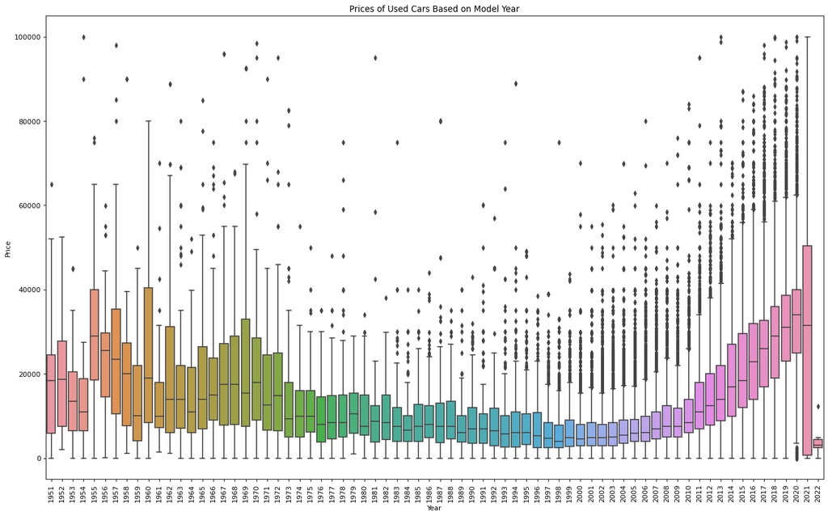

```python
# price based on model year

df['year'] = pd.to_numeric(df['year'], downcast='integer')
data = df[df['year'] > 1950]

figure(figsize=(20, 12), dpi=80)
fig = sns.boxplot(x='year', y="price", data=data)
plt.xlabel('Year')
plt.ylabel('Price')
plt.title('Prices of Used Cars Based on Model Year')
plt.xticks(rotation=90);
```

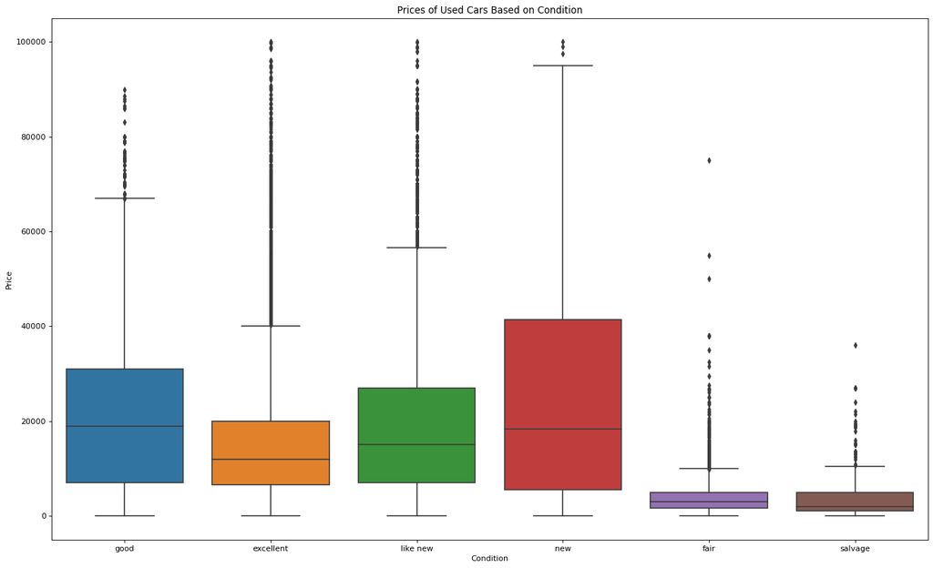

```python
# price based on condition

figure(figsize=(20, 12), dpi=80)
sns.boxplot(data = df, x = 'condition', y ='price')
plt.xlabel('Condition')
plt.ylabel('Price')
plt.title('Prices of Used Cars Based on Condition')
```

[figure not shown]

```python
# price based on paint color

figure(figsize=(12, 9), dpi=80)
sns.boxplot(data = df, x = 'paint_color', y ='price')
plt.xlabel('Paint Color')
plt.ylabel('Price')
plt.title('Prices of Used Cars Based on Condition')
```

The plot below shows prices in a boxplot divided by the type of transmission. It appears that manual and automatic transmissions are worth roughly the same.

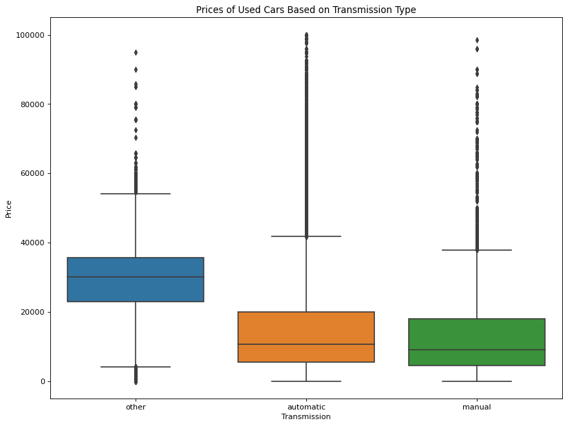

```python
# price based on transmission type

figure(figsize=(12, 9), dpi=80)
sns.boxplot(data = df, x = 'transmission', y ='price')
plt.xlabel('Transmission')
plt.ylabel('Price')
plt.title('Prices of Used Cars Based on Transmission Type')
```

One interesting factor is the state in which the car is listed in. One would expect that [highest cost of living states](https://wisevoter.com/state-rankings/cost-of-living-by-state/#:~:text=The%20ten%20states%20with%20the,of%20living%20index%20of%20184.) would have the most expensive cars, but according to the plot below, there doesn't seem to be a significant correlation at first glance. This would be an interesting question to do another project on. Nonetheless, the state the car is sold in does seem to have an effect on the price.

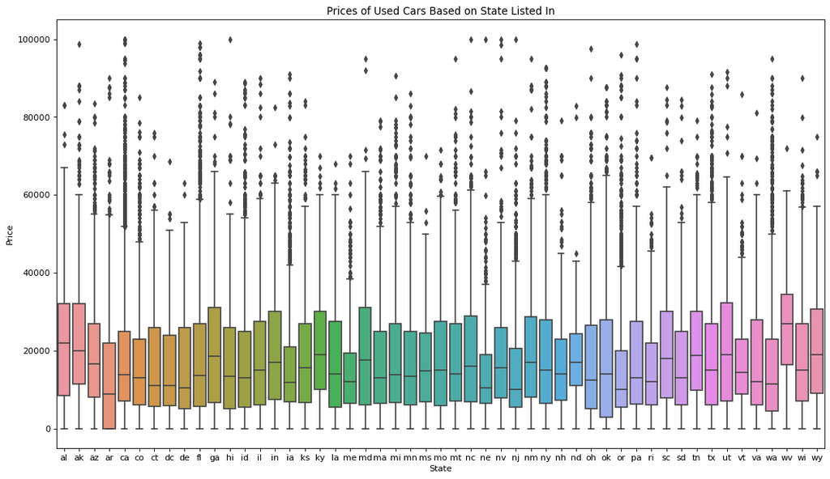

```python
# price based on state

figure(figsize=(16, 9), dpi=80)
sns.boxplot(data = df, x = 'state', y ='price')
plt.xlabel('State')
plt.ylabel('Price')
plt.title('Prices of Used Cars Based on State Listed In')
```

### Machine Learning

Now that we have an idea of how different factors affect the price of used vehicles, the next step is to create a model that predicts the price of a car given different factors. For our model, we will use [random forest regression](https://towardsdatascience.com/random-forest-regression-5f605132d19d), which uses decision trees and ensemble learning. We will use the sklearn python library to do this.

```python
df.head(5)
```

|  | price | year | manufacturer | model | condition | fuel | odometer | transmission | paint_color | state | car |
| --- | --- | --- | --- | --- | --- | --- | --- | --- | --- | --- | --- |
| 27 | 33590 | 2014 | gmc | sierra 1500 crew cab slt | good | gas | 57923.0 | other | white | al | gmc sierra |
| 28 | 22590 | 2010 | chevrolet | silverado 1500 | good | gas | 71229.0 | other | blue | al | chevrolet silverado |
| 29 | 39590 | 2020 | chevrolet | silverado 1500 crew | good | gas | 19160.0 | other | red | al | chevrolet silverado |
| 30 | 30990 | 2017 | toyota | tundra double cab sr | good | gas | 41124.0 | other | red | al | toyota tundra |
| 31 | 15000 | 2013 | ford | f-150 xlt | excellent | gas | 128000.0 | automatic | black | al | ford f-150 |

Our data needs a little more processing before we can feed it to the model. As we can see above, columns such as manufacturer have string values. For this to be usable in the model, they have to be converted to integers. For example, we could map gmc -> 0, chevorlet -> 1, toyota -> 2, and so on. We will use the [LabelEncoder](https://scikit-learn.org/stable/modules/generated/sklearn.preprocessing.LabelEncoder.html) function to do this for us.

```python
# preparing the data for machine learning
from sklearn import preprocessing
label_encoder = preprocessing.LabelEncoder()
df['condition']= label_encoder.fit_transform(df['condition'])
df['transmission']= label_encoder.fit_transform(df['transmission'])
df['paint_color']= label_encoder.fit_transform(df['paint_color'])
df['state']= label_encoder.fit_transform(df['state'])
df['manufacturer']= label_encoder.fit_transform(df['manufacturer'])
df['model']= label_encoder.fit_transform(df['model'])
df['fuel']= label_encoder.fit_transform(df['fuel'])
df.head(5)
```

|  | price | year | manufacturer | model | condition | fuel | odometer | transmission | paint_color | state | car |
| --- | --- | --- | --- | --- | --- | --- | --- | --- | --- | --- | --- |
| 27 | 33590 | 2014 | 4 | 9091 | 2 | 2 | 57923.0 | 2 | 10 | 1 | gmc sierra |
| 28 | 22590 | 2010 | 1 | 9304 | 2 | 2 | 71229.0 | 2 | 1 | 1 | chevrolet silverado |
| 29 | 39590 | 2020 | 1 | 9317 | 2 | 2 | 19160.0 | 2 | 8 | 1 | chevrolet silverado |
| 30 | 30990 | 2017 | 10 | 10717 | 2 | 2 | 41124.0 | 2 | 8 | 1 | toyota tundra |
| 31 | 15000 | 2013 | 3 | 5208 | 0 | 2 | 128000.0 | 0 | 0 | 1 | ford f-150 |

```python
x = df.loc[:, ['year', 'condition', 'fuel', 'odometer', 'transmission', 'paint_color', 'state', 'manufacturer', 'model']]
y = df.loc[:, ['price']]
```

We will now store these values in x and y. The one point in x represents all the factors that make up one point in the price y. We will then split this data into a training set and a verification set using the [train_test_split](https://scikit-learn.org/stable/modules/generated/sklearn.model_selection.train_test_split.html) function. We will then fit the model using our training data using [RandomForestRegressor](https://scikit-learn.org/stable/modules/generated/sklearn.ensemble.RandomForestRegressor.html). As we can see, we have a pretty decent accuracy in predicting prices on our testing set.

```python
from sklearn.model_selection import train_test_split
x_train, x_test, y_train, y_test = train_test_split(x, y, test_size = 0.2, random_state = 25)

from sklearn.ensemble import RandomForestRegressor
rf_reg = RandomForestRegressor()
rf_reg.fit(x_train, y_train)
y_pred= rf_reg.predict(x_test)
print("Accuracy on Training set: ",rf_reg.score(x_train,y_train))
print("Accuracy on Testing set: ",rf_reg.score(x_test,y_test))
```

```
Accuracy on Training set:  0.9725389910646356
Accuracy on Testing set:  0.8357956068852337
```

Below is a graph comparing the actual price with our predicted price on 114 different cars from out dataset. For some cars, it is really good at predicting the price, but on others it is far off. This could be due to not having enough training data on the car.

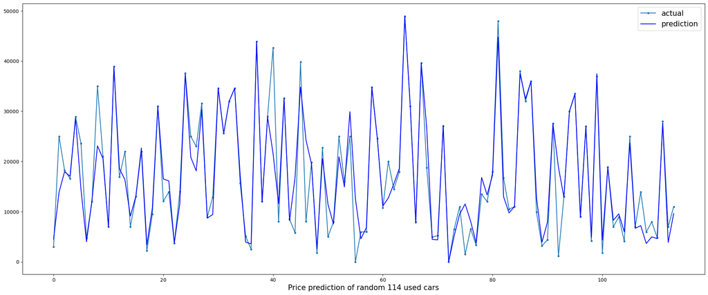

```python
y = y_test[1::300]
y_total = y_pred[1::300]
number = y_total.size
aa=[x for x in range(number)]
plt.figure(figsize=(25,10))
plt.plot(aa, y[:number], marker='.', label="actual")
plt.plot(aa, y_total[:number], 'b', label="prediction")
plt.xlabel('Price prediction of random {} used cars'.format(number), size=15)
plt.legend(fontsize=15)
plt.show()
```

Our above model runs with the manufacturer and model as sepereate features. This runs into the problem we described earlier, where many similar models have slightly different model names, based on the user naming it differently on craigslist. This thins out our dataset, and could be the cause of a lower accuracy. Lets try using the column we created called 'car' instead.

```
Accuracy on Training set:  0.9706127612925108
Accuracy on Testing set:  0.8299995093811008
```

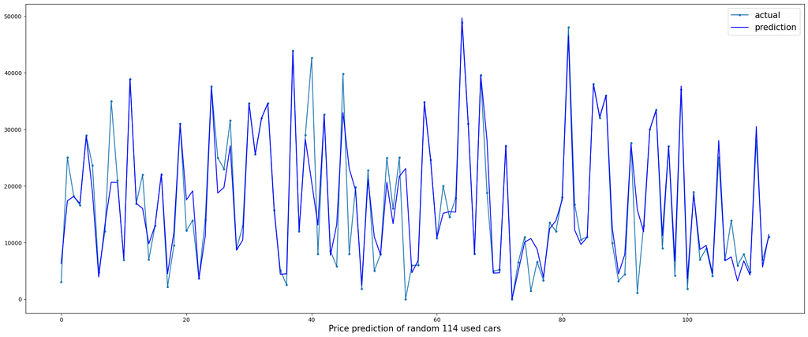

```python
# maybe we can increase accuracy by running each car individually
df['car']= label_encoder.fit_transform(df['car'])
x = df.loc[:, ['year', 'condition', 'fuel', 'odometer', 'transmission', 'paint_color', 'state', 'car']]
y = df.loc[:, ['price']]


x_train, x_test, y_train, y_test = train_test_split(x, y, test_size = 0.2, random_state = 25)

rf_reg = RandomForestRegressor()
rf_reg.fit(x_train, y_train)
y_pred= rf_reg.predict(x_test)
print("Accuracy on Training set: ",rf_reg.score(x_train,y_train))
print("Accuracy on Testing set: ",rf_reg.score(x_test,y_test))

y = y_test[1::300]
y_total = y_pred[1::300]
number = y_total.size
aa=[x for x in range(number)]
plt.figure(figsize=(25,10))
plt.plot(aa, y[:number], marker='.', label="actual")
plt.plot(aa, y_total[:number], 'b', label="prediction")
plt.xlabel('Price prediction of random {} used cars'.format(number), size=15)
plt.legend(fontsize=15)
plt.show()
```

Unfortunately, our accuracy didn't change significantly. There are other ways that we could try to fine tune the model, but I will leave that to you to tinker and figure out. Refer to [this article](https://towardsdatascience.com/improving-random-forest-in-python-part-1-893916666cd) for some possible methods. Finally, lets illustrate the impact of each feature on price in one last plot below. As you can see, the three most important factos are the mileage, year, and manufacturer/model of the car itself.

```
<BarContainer object of 8 artists>
```

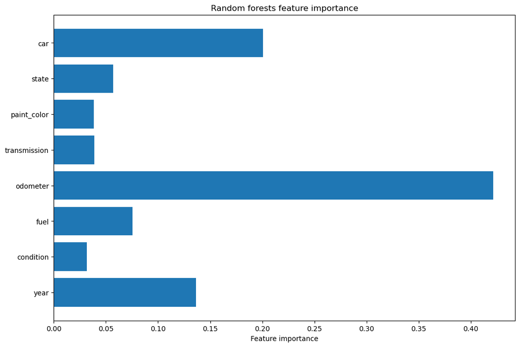

```python
plt.figure(figsize=(12, 8))
plt.title('Random forests feature importance')
plt.xlabel('Feature importance')

# create horizontal bar graph with features on the y-axis and the importance of each feature as the width
plt.barh(rf_reg.feature_names_in_, rf_reg.feature_importances_)
```

### Final Insights

The final step of the data science process is drawing conclusions and make decisions based on the previous steps. I hope that by following through this tutorial, you have gained a better understanding of the data science process. Additionally, we have been able to create a model that will be able to give the user an idea of the price of a certain used car, based on a number of factors. The next time you are looking at used cars on craigslist, for example, you could be able to get an idea of how much a car should be worth by plugging in the factors into our model. With this tool, hopefully you can be able to make a more informed decision on which used car you want to buy. Thank you for joining me in going through the data science lifecycle!